# Lista 1 - Exercício A

Gustavo Tironi

08/05/2023

# 1 Configurando o ambiente

Inicialmente, como eu já tinha o R em meu computador, foi necessário instalar o RStudio e as bibliotecas usadas. Para isso, foi necessário instalar o RStudio pela internet, e então instalar a biblioteca **ggplot2**, necessária para esse exercício. Para isso, foi necessário o seguinte comando:

```
install.packages("ggplot2")
```

Com isso feito, pude começar a desenvolver os gráficos.

# 2 Desenvolvendo os gráficos - Anscombe

Inicialmente, plotei um gráfico de dispersão padrão, para as variáveis x1 e y1, usando o **ggplot**. Com isso, obtive o seguinte resultado:

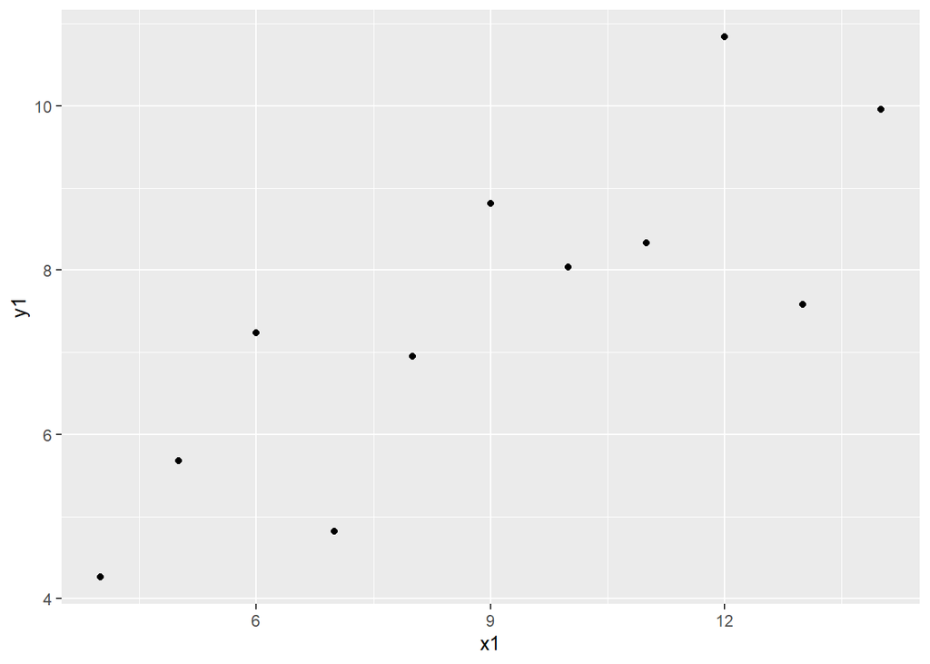

Contudo, ainda era necessário adicionar a linha de tendência desses pontos. Para isso, adicionei a seguinte linha de comando:

```
geom_smooth(method = "lm", color = "Red", se = FALSE)
```

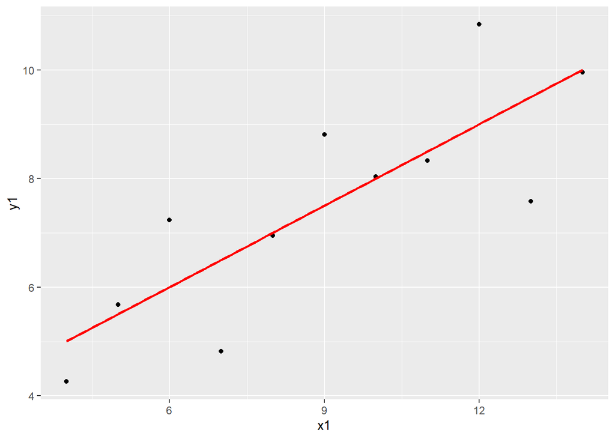

Então resolvi adicionar um título ao gráfico, retirar as linhas de grade e formatar a areá de plotagem, usando para isso os seguintes comandos:

```
ggtitle("Gráfico x1 vs y1") +
theme_test() +
theme(plot.title = element_text(hjust=0.5))
```

O **primeiro** comando, define o título, o **segundo** comando define um tema pré-definido do ggplot e o **terceiro** centraliza o título, ficando com um gráfico dessa forma:

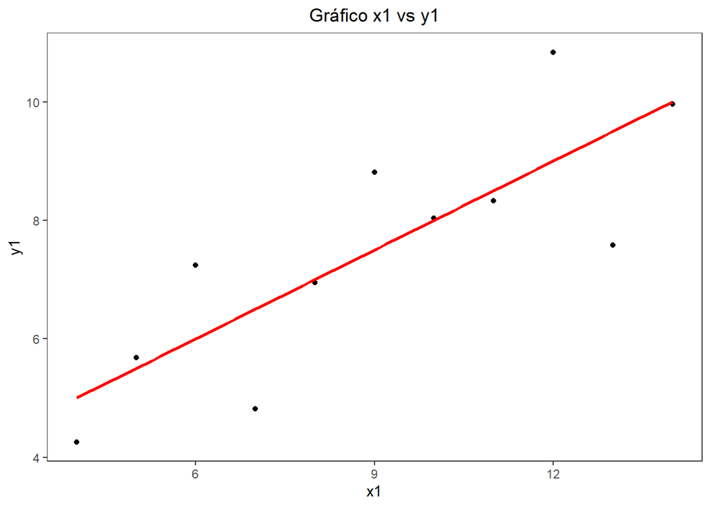

Então, para maior aproximação ao gráfico de Anscombe apresentado na internet, foram formatados os eixos, usando os seguintes comandos ou uma variação deles:

```
scale_y_continuous(breaks = seq(4, 12, 2), limits = c(4, 12)) +
scale_x_continuous(breaks = seq(4, 18, 2), limits = c(4, 18))
```

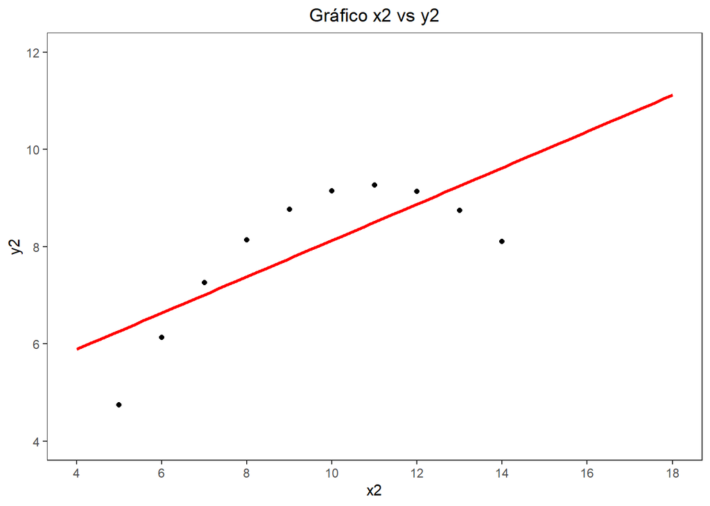

Com isso, podemos usar esse modelo e montar os gráficos para os quatro conjuntos de dados de Anscombe. Após isso, basta juntarmos os gráficos em um mesmo layout. Para tal, usei a biblioteca **gridExtra**, usando o seguinte comando.

```
grid.arrange(p1, p2, p3, p4, ncol=2, nrow=2)
```

Ficando com o seguinte resultado:

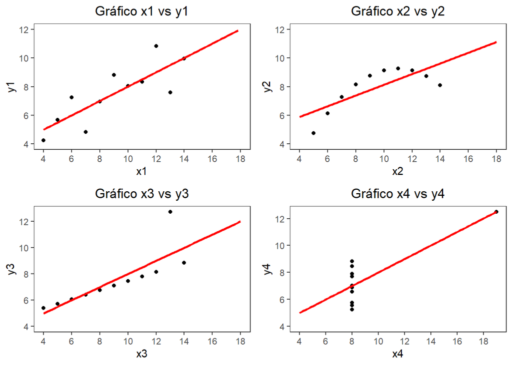

Ao fim, achei que ficaria mais interessante retirar os títulos dos gráficos individualmente e colocar um título geral, ficando da seguinte forma:

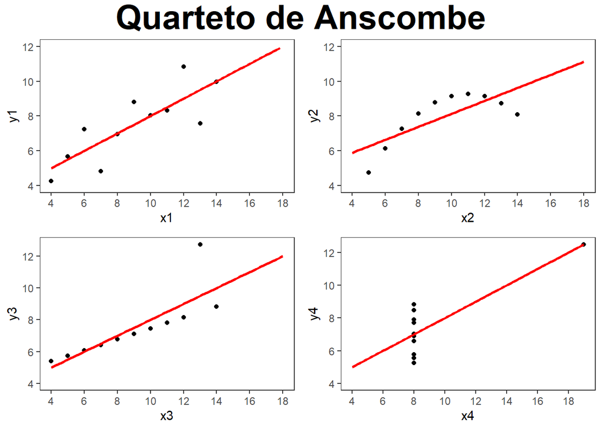

Assim finalizei a tarefa, plotando o quarteto de Anscombe completamente e o código final ficou da seguinte forma:

```
# Carregando os pacotes -------------------------------------------------
library(ggplot2)
library(gridExtra)
library(grid)

# Definindo os gráficos -------------------------------------------------
p1 <- ggplot(anscombe, aes(x = x1, y = y1)) +
  geom_point() +
  geom_smooth(method = "lm", color = "Red", se = FALSE, fullrange = TRUE) +
  theme_test() +
  theme(plot.title = element_text(hjust=0.5)) +
  scale_y_continuous(breaks = seq(4, 12, 2),
                     limits = c(4, 12)) +
  scale_x_continuous(breaks = seq(4, 18, 2),
                     limits = c(4, 18))

p2 <- ggplot(anscombe, aes(x = x2, y = y2)) +
  geom_point() +
  geom_smooth(method = "lm", color = "Red", se = FALSE, fullrange = TRUE) +
  theme_test() +
  theme(plot.title = element_text(hjust=0.5)) +
  scale_y_continuous(breaks = seq(4, 12, 2),
                     limits = c(4, 12)) +
  scale_x_continuous(breaks = seq(4, 18, 2),
                     limits = c(4, 18))

p3 <- ggplot(anscombe, aes(x = x3, y = y3)) +
  geom_point() +
  geom_smooth(method = "lm", color = "Red", se = FALSE, fullrange = TRUE) +
  theme_test() +
  theme(plot.title = element_text(hjust=0.5)) +
  scale_y_continuous(breaks = seq(4, 12, 2),
                     limits = c(4, NA)) +
  scale_x_continuous(breaks = seq(4, 18, 2),
                     limits = c(4, 18))

p4 <- ggplot(anscombe, aes(x = x4, y = y4)) +
  geom_point() +
  geom_smooth(method = "lm", color = "Red", se = FALSE, fullrange = TRUE) +
  theme_test() +
  theme(plot.title = element_text(hjust=0.5)) +
  scale_y_continuous(breaks = seq(4, 12, 2),
                     limits = c(4, NA)) +
  scale_x_continuous(breaks = seq(4, 18, 2),
                     limits = c(4, NA))

# Plotando os gráficos juntos -------------------------------------------
grid.arrange(p1, p2,
             p3, p4,
             ncol=2, nrow=2,
             top = textGrob("Quarteto de Anscombe",gp=gpar(fontsize=28,font=2)))
```